# Part2

*This section of the project is a report about the employees. This report summarizes the total revenue each employee generates, how many products they sell, what products they are able to sell, their sales performance across years and how they do in different regions. Using various statistics and graphs/tables, we will explore what drives their performance and suggestions on how performance can be improved. At the very end, there is a summary of the strength and weakness of each employee.*

Import modules that are needed

```python
# Import libraries
import sqlite3
import pandas as pd
import matplotlib.pyplot as plt
import numpy as np
from IPython import display
import numpy as np
import matplotlib.pyplot as plt
import seaborn as sns
import scipy.stats as stats
```

Read in the sqlite3 dataset that contains the employee data

```python
# Import Dataset
con = sqlite3.connect("northwind.sqlite")
```

## General Employee Analysis

The first step in the study is to see the employees table. This step will show how many employees are there and how many sales representatives there are. The Employee ID , Employee , First Name , LastName and title are the important information being looked at. Total number of employees holding each title is counted here.

We see below that there are 6 sales representatves with 1 Vice President , 1 Sales Manager & an Inside sales coordinater

```python
## Reading the summary of tables from the sqlite file
df=pd.read_sql('SELECT * FROM sqlite_schema WHERE type = "table"', con)
print(df)
```

```
     type                  name              tbl_name  rootpage  \
0   table            Categories            Categories         2
1   table       sqlite_sequence       sqlite_sequence         3
2   table  CustomerCustomerDemo  CustomerCustomerDemo        28
3   table  CustomerDemographics  CustomerDemographics        30
4   table             Customers             Customers        32
5   table             Employees             Employees        38
6   table   EmployeeTerritories   EmployeeTerritories        68
7   table         Order Details         Order Details        70
8   table                Orders                Orders        92
9   table              Products              Products       128
10  table               Regions               Regions       132
11  table              Shippers              Shippers       133
12  table             Suppliers             Suppliers       134
13  table           Territories           Territories       135
```

[output cut: 16 more lines]

A SQL query is used to join different tables together and is then converted into a pandas dataframe for analysis

```python
# Create Query Used for Analysis
query1 = """
    SELECT e.EmployeeID, o.OrderID, e.LastName, e.FirstName, e.Title, od.UnitPrice, od.Quantity, od.Discount, p.ProductName, o.OrderDate, ((od.UnitPrice-od.Discount)*od.Quantity) as 'TotalSold', o.ShipCountry, c.CategoryName
    FROM 'Orders' as o
    INNER JOIN 'Order Details' as od ON o.OrderID = od.OrderID
    INNER JOIN 'Products' as p ON od.ProductID = p.ProductID
    INNER JOIN 'Categories' as c ON p.CategoryID = c.CategoryID
    INNER JOIN 'Employees' as e ON o.EmployeeID = e.EmployeeID
    """
emp = pd.read_sql(query1, con)
emp
```

|  | EmployeeID | OrderID | LastName | FirstName | Title | UnitPrice | Quantity | Discount | ProductName | OrderDate | TotalSold | ShipCountry | CategoryName |
| --- | --- | --- | --- | --- | --- | --- | --- | --- | --- | --- | --- | --- | --- |
| 0 | 5 | 10248 | Buchanan | Steven | Sales Manager | 14.00 | 12 | 0.00 | Queso Cabrales | 1996-07-04 00:00:00.000 | 168.00 | France | Dairy Products |
| 1 | 5 | 10248 | Buchanan | Steven | Sales Manager | 9.80 | 10 | 0.00 | Singaporean Hokkien Fried Mee | 1996-07-04 00:00:00.000 | 98.00 | France | Grains/Cereals |
| 2 | 5 | 10248 | Buchanan | Steven | Sales Manager | 34.80 | 5 | 0.00 | Mozzarella di Giovanni | 1996-07-04 00:00:00.000 | 174.00 | France | Dairy Products |
| 3 | 6 | 10249 | Suyama | Michael | Sales Representative | 18.60 | 9 | 0.00 | Tofu | 1996-07-05 00:00:00.000 | 167.40 | Germany | Produce |
| 4 | 6 | 10249 | Suyama | Michael | Sales Representative | 42.40 | 40 | 0.00 | Manjimup Dried Apples | 1996-07-05 00:00:00.000 | 1696.00 | Germany | Produce |
| ... | ... | ... | ... | ... | ... | ... | ... | ... | ... | ... | ... | ... | ... |
| 2150 | 1 | 11077 | Davolio | Nancy | Sales Representative | 33.25 | 2 | 0.03 | Wimmers gute Semmelknödel | 1998-05-06 00:00:00.000 | 66.44 | USA | Grains/Cereals |
| 2151 | 1 | 11077 | Davolio | Nancy | Sales Representative | 17.00 | 1 | 0.00 | Louisiana Hot Spiced Okra | 1998-05-06 00:00:00.000 | 17.00 | USA | Condiments |
| 2152 | 1 | 11077 | Davolio | Nancy | Sales Representative | 15.00 | 2 | 0.01 | Röd Kaviar | 1998-05-06 00:00:00.000 | 29.98 | USA | Seafood |
| 2153 | 1 | 11077 | Davolio | Nancy | Sales Representative | 7.75 | 4 | 0.00 | Rhönbräu Klosterbier | 1998-05-06 00:00:00.000 | 31.00 | USA | Beverages |
| 2154 | 1 | 11077 | Davolio | Nancy | Sales Representative | 13.00 | 2 | 0.00 | Original Frankfurter grüne Soße | 1998-05-06 00:00:00.000 | 26.00 | USA | Condiments |

2155 rows × 13 columns

The created dataset is cleaned to make analysis easier such as changing the order date to only show the year, combining the first and last name of an employee together, and changing categorical variable into a category type.

```python
# Clean Dataset
emp['OrderDate'] = pd.DatetimeIndex(emp['OrderDate']).year
emp['EmployeeName'] = emp["FirstName"] + " " + emp["LastName"]
emp[["Title","LastName","EmployeeID","OrderID","FirstName","ProductName","OrderDate"]] = emp[["Title","LastName","EmployeeID","OrderID","FirstName","ProductName","OrderDate"]].apply(lambda x: x.astype("category"))
emp
```

|  | EmployeeID | OrderID | LastName | FirstName | Title | UnitPrice | Quantity | Discount | ProductName | OrderDate | TotalSold | ShipCountry | CategoryName | EmployeeName |
| --- | --- | --- | --- | --- | --- | --- | --- | --- | --- | --- | --- | --- | --- | --- |
| 0 | 5 | 10248 | Buchanan | Steven | Sales Manager | 14.00 | 12 | 0.00 | Queso Cabrales | 1996 | 168.00 | France | Dairy Products | Steven Buchanan |
| 1 | 5 | 10248 | Buchanan | Steven | Sales Manager | 9.80 | 10 | 0.00 | Singaporean Hokkien Fried Mee | 1996 | 98.00 | France | Grains/Cereals | Steven Buchanan |
| 2 | 5 | 10248 | Buchanan | Steven | Sales Manager | 34.80 | 5 | 0.00 | Mozzarella di Giovanni | 1996 | 174.00 | France | Dairy Products | Steven Buchanan |
| 3 | 6 | 10249 | Suyama | Michael | Sales Representative | 18.60 | 9 | 0.00 | Tofu | 1996 | 167.40 | Germany | Produce | Michael Suyama |
| 4 | 6 | 10249 | Suyama | Michael | Sales Representative | 42.40 | 40 | 0.00 | Manjimup Dried Apples | 1996 | 1696.00 | Germany | Produce | Michael Suyama |
| ... | ... | ... | ... | ... | ... | ... | ... | ... | ... | ... | ... | ... | ... | ... |
| 2150 | 1 | 11077 | Davolio | Nancy | Sales Representative | 33.25 | 2 | 0.03 | Wimmers gute Semmelknödel | 1998 | 66.44 | USA | Grains/Cereals | Nancy Davolio |
| 2151 | 1 | 11077 | Davolio | Nancy | Sales Representative | 17.00 | 1 | 0.00 | Louisiana Hot Spiced Okra | 1998 | 17.00 | USA | Condiments | Nancy Davolio |
| 2152 | 1 | 11077 | Davolio | Nancy | Sales Representative | 15.00 | 2 | 0.01 | Röd Kaviar | 1998 | 29.98 | USA | Seafood | Nancy Davolio |
| 2153 | 1 | 11077 | Davolio | Nancy | Sales Representative | 7.75 | 4 | 0.00 | Rhönbräu Klosterbier | 1998 | 31.00 | USA | Beverages | Nancy Davolio |
| 2154 | 1 | 11077 | Davolio | Nancy | Sales Representative | 13.00 | 2 | 0.00 | Original Frankfurter grüne Soße | 1998 | 26.00 | USA | Condiments | Nancy Davolio |

2155 rows × 14 columns

The bar plot below shows the sales amount for each kinds of products. We found that beverages are the most sold product, while produce is the least sold product.

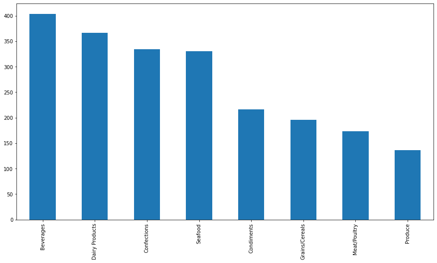

```python
table = emp.CategoryName.value_counts()
table.plot.bar(figsize=(15, 8))
plt.xticks(rotation = 90)
plt.show()
```

The plot below was created to examine which country products are most sold to. It can be seen that the USA, Germany, and Brazil are the three top countries products are sold to.

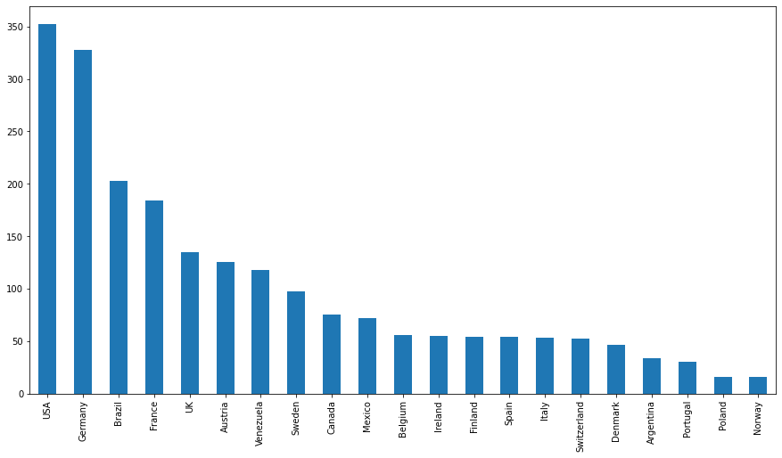

```python
table = emp.ShipCountry.value_counts()
table.plot.bar(figsize=(15, 8))
plt.xticks(rotation = 90)
plt.show()
```

The table below was created to compare the total sales for each employee.

We can see that Margaret Peacock had the largest overall revenue generated, while Steven Buchanan has the lowest overall revenue generated

```python
# Total discounts offered by employee
emp_total_revenue = emp.groupby(["EmployeeName"])[["TotalSold"]].sum()
emp_total_revenue
```

| EmployeeName | TotalSold |
| --- | --- |
| Andrew Fuller | 177378.66 |
| Anne Dodsworth | 82740.15 |
| Janet Leverling | 212636.35 |
| Laura Callahan | 133003.63 |
| Margaret Peacock | 249480.80 |
| Michael Suyama | 78000.15 |
| Nancy Davolio | 201667.70 |
| Robert King | 140884.49 |
| Steven Buchanan | 75344.70 |

The plot below shows how all employees have been doing over the past 3 years.

We can see 7 employees that had a decrease in total sales in 1998 compare to the prior year, while only 2 employees performed better than the prior year.

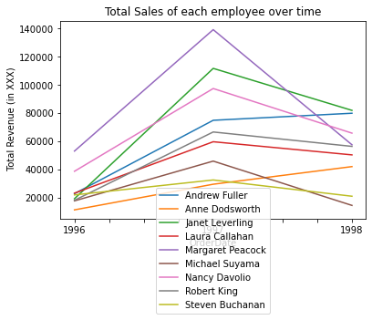

```python
# Line chart 1: Plot the Total Sales of each employee over time
emp_total_sold = emp.groupby(["EmployeeName","OrderDate"])[["TotalSold"]].sum()
emp_total_sold.pivot_table(values="TotalSold", index = "OrderDate", columns = "EmployeeName").plot()
plt.ylabel(" Total Revenue (in XXX)")
plt.title("Total Sales of each employee over time")
plt.legend(loc = "lower center", bbox_to_anchor = (0.5, -0.5))
```

The plot below shows the amount of product a specific employee sold to each country

Due to having too much data all at once, it is hard to see the comparison of what an employee sold the most. In the next section, we will split the data to only show a specific employee's data so we can analyze how well that employee is doing.

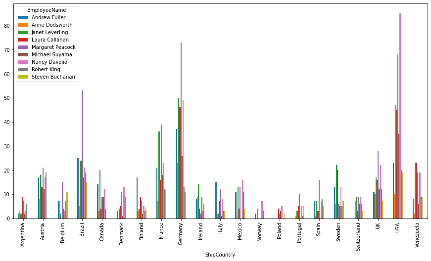

```python
table = pd.crosstab(emp.ShipCountry,emp.EmployeeName)
table.plot.bar(figsize=(15, 8))
plt.xticks(rotation = 90)
plt.show()
```

## Specific Employee Analysis

```python
#Allows iteration of employees
def sort_data(i):
    #Sorts data to only the specific employee's
    currEmp = emp[(emp["EmployeeID"] == i)]

    return currEmp
```

### Nancy Davolio - Employee ID 1

The following code creates various statistics for an employee to measure their performance

```python
current = sort_data(1)
# dataset for total revenue by product name
empSold = current.groupby("ProductName")[["TotalSold"]].sum()
# dataset for total revenue by product category
empSoldCategory = current.groupby("CategoryName")[["TotalSold"]].sum()
# dataset for products employee didn't sell
empNotSold = empSold.loc[empSold.TotalSold == 0]
# dataset for employee's total sold by year
emp_total_sold = current.groupby(["OrderDate"])[["TotalSold"]].sum()
# Worst 3 products sold by employee
bottom_3 = empSold.sort_values(by=['TotalSold']).iloc[:3]
# best 3 products sold by employee
top_3 = empSold.sort_values(by=['TotalSold']).iloc[-3:]
# dataset for employee's total revenue by country
empSoldCountry = empSold = current.groupby("ShipCountry")[["TotalSold"]].sum()
```

The graph below shows the total sales trend of an employee by year.

It can be seen that they generated less revenue than the prior year.

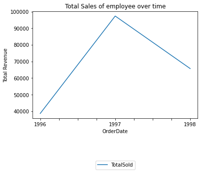

```python
# Total sold by employee over time
emp_total_sold.pivot_table(values="TotalSold", index = "OrderDate").plot()
plt.ylabel("Total Revenue")
plt.title("Total Sales of employee over time")
plt.legend(loc = "lower center", bbox_to_anchor = (0.5, -0.5))
```

The table below shows the total amount sold by an employee by category.

It can be seen that they have sold beverages the most, while grains/cereals are sold the least.

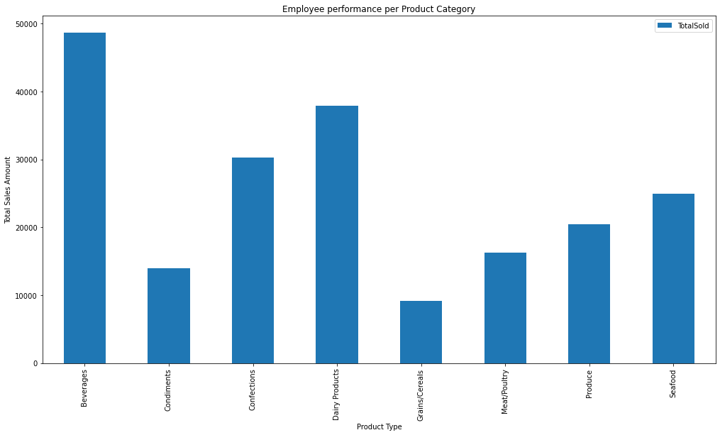

```python
# Total sold by employee by category
empSoldCategory.plot(kind="bar",figsize=(17, 9))
plt.title("Employee performance per Product Category")
plt.xlabel("Product Type")
plt.ylabel("Total Sales Amount")
```

The table below shows the total amount sold by an employee by country.

It can be seen that they have sold to the USA the most, while Argentina is sold to the least.

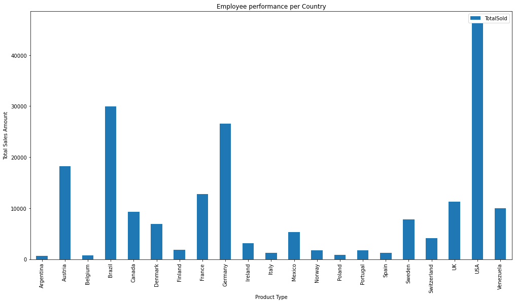

```python
# Total sold by employee by country
empSoldCountry.plot(kind="bar",figsize=(17, 9))
plt.title("Employee performance per Country")
plt.xlabel("Product Type")
plt.ylabel("Total Sales Amount")
plt.show()
```

The table below shows the 3 top products sold by the employee.

```python
top_3
```

| ProductName | TotalSold |
| --- | --- |
| Tarte au sucre | 9846.15 |
| Manjimup Dried Apples | 13402.00 |
| CÃ´te de Blaye | 23976.75 |

The table below shows the products that have not been sold by the employee before.

```python
empNotSold
```

| ProductName | TotalSold |
| --- | --- |
| Gravad lax | 0.0 |
| Gustaf's Knäckebröd | 0.0 |
| Laughing Lumberjack Lager | 0.0 |
| Mishi Kobe Niku | 0.0 |
| Sasquatch Ale | 0.0 |

#### Summary of Nancy Davolio

##### Strength

- This employee is most successful in selling beverages.
- Their top most sold products are Tarte au sucre, Manjimup Dried Apples, and CÃ´te de Blaye.

##### Areas of improvement

- This employee has been selling less in the most recent year and should try to improve their overall sales
- This employee has 5 types of products they have never sold before, they should see if they can try to sell them

### Andrew Fuller - Employee ID 2

The following code creates various statistics for an employee to measure their performance

```python
current = sort_data(2)
# dataset for total revenue by product name
empSold = current.groupby("ProductName")[["TotalSold"]].sum()
# dataset for total revenue by product category
empSoldCategory = current.groupby("CategoryName")[["TotalSold"]].sum()
# dataset for products employee didn't sell
empNotSold = empSold.loc[empSold.TotalSold == 0]
# dataset for employee's total sold by year
emp_total_sold = current.groupby(["OrderDate"])[["TotalSold"]].sum()
# Worst 3 products sold by employee
bottom_3 = empSold.sort_values(by=['TotalSold']).iloc[:3]
# best 3 products sold by employee
top_3 = empSold.sort_values(by=['TotalSold']).iloc[-3:]
# dataset for employee's total revenue by country
empSoldCountry = empSold = current.groupby("ShipCountry")[["TotalSold"]].sum()
```

The graph below shows the total sales trend of an employee by year.

It can be seen that they generated more revenue than the prior year.

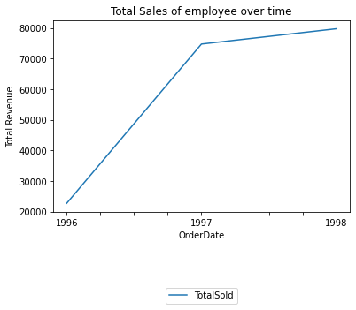

```python
# Total sold by employee over time
emp_total_sold.pivot_table(values="TotalSold", index = "OrderDate").plot()
plt.ylabel("Total Revenue")
plt.title("Total Sales of employee over time")
plt.legend(loc = "lower center", bbox_to_anchor = (0.5, -0.5))
```

The table below shows the total amount sold by an employee by category.

It can be seen that they have sold beverages the most, while produce is sold the least.

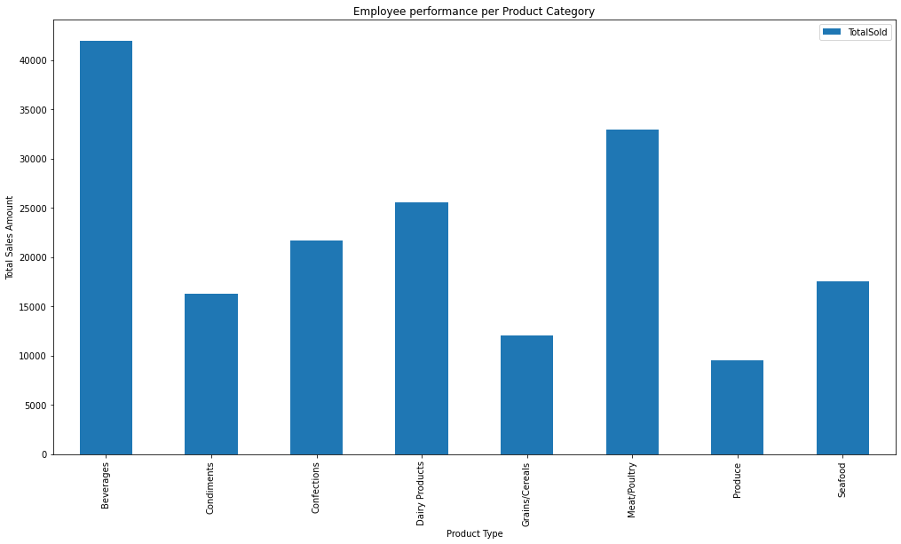

```python
# Total sold by employee by category
empSoldCategory.plot(kind="bar",figsize=(17, 9))
plt.title("Employee performance per Product Category")
plt.xlabel("Product Type")
plt.ylabel("Total Sales Amount")
```

The table below shows the total amount sold by an employee by country.

It can be seen that they have sold to Germany the most, while Argentina is sold to the least.

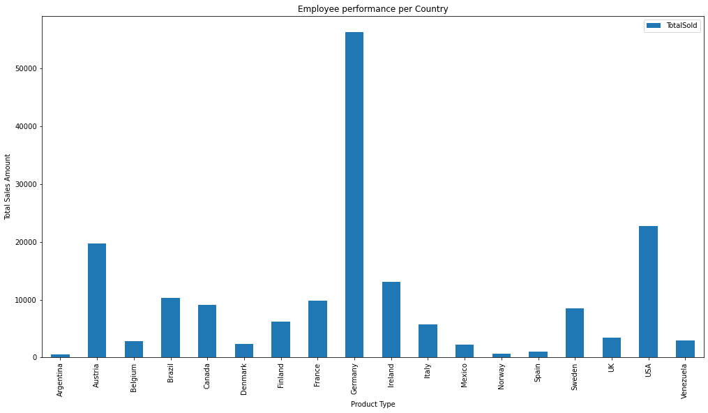

```python
# Total sold by employee by country
empSoldCountry.plot(kind="bar",figsize=(17, 9))
plt.title("Employee performance per Country")
plt.xlabel("Product Type")
plt.ylabel("Total Sales Amount")
plt.show()
```

The table below shows the 3 top products sold by the employee.

```python
top_3
```

| ProductName | TotalSold |
| --- | --- |
| Tarte au sucre | 7393.00 |
| Thüringer Rostbratwurst | 17809.76 |
| Côte de Blaye | 26083.10 |

The table below shows the products that have not been sold by the employee before.

```python
empNotSold
```

| ProductName | TotalSold |
| --- | --- |
| Aniseed Syrup | 0.0 |
| Chef Anton's Gumbo Mix | 0.0 |
| Chocolade | 0.0 |
| Gravad lax | 0.0 |
| Queso Manchego La Pastora | 0.0 |
| RÃ¶d Kaviar | 0.0 |
| Sir Rodney's Marmalade | 0.0 |
| Tofu | 0.0 |
| Valkoinen suklaa | 0.0 |

#### Summary of Andrew Fuller

##### Areas of improvement

- This employee has 9 types of products they have never sold before, they should see if they can try to sell them

### Janet Leverling - Employee ID 3

The following code creates various statistics for an employee to measure their performance

```python
current = sort_data(3)
# dataset for total revenue by product name
empSold = current.groupby("ProductName")[["TotalSold"]].sum()
# dataset for total revenue by product category
empSoldCategory = current.groupby("CategoryName")[["TotalSold"]].sum()
# dataset for products employee didn't sell
empNotSold = empSold.loc[empSold.TotalSold == 0]
# dataset for employee's total sold by year
emp_total_sold = current.groupby(["OrderDate"])[["TotalSold"]].sum()
# Worst 3 products sold by employee
bottom_3 = empSold.sort_values(by=['TotalSold']).iloc[:3]
# best 3 products sold by employee
top_3 = empSold.sort_values(by=['TotalSold']).iloc[-3:]
# dataset for employee's total revenue by country
empSoldCountry = empSold = current.groupby("ShipCountry")[["TotalSold"]].sum()
```

The graph below shows the total sales trend of an employee by year.

It can be seen that they generated less revenue than the prior year.

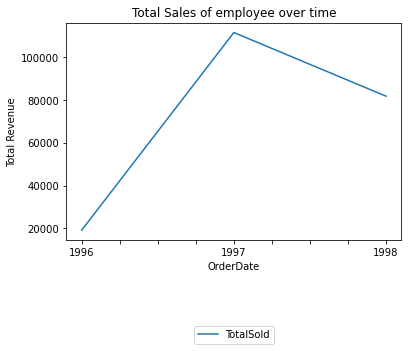

```python
# Total sold by employee over time
emp_total_sold.pivot_table(values="TotalSold", index = "OrderDate").plot()
plt.ylabel("Total Revenue")
plt.title("Total Sales of employee over time")
plt.legend(loc = "lower center", bbox_to_anchor = (0.5, -0.5))
```

The table below shows the total amount sold by an employee by category.

It can be seen that they have sold beverages the most, while condominiums and produce are sold the least.

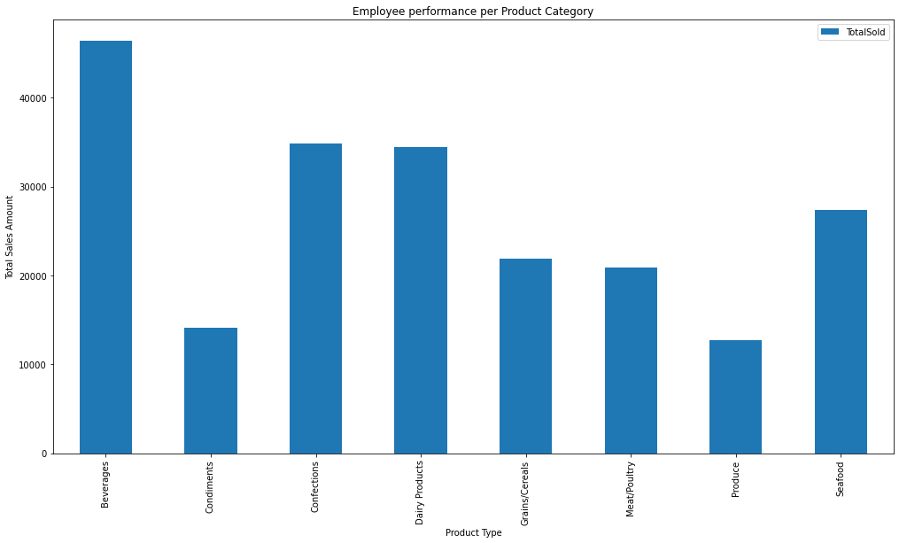

```python
# Total sold by employee by category
empSoldCategory.plot(kind="bar",figsize=(17, 9))
plt.title("Employee performance per Product Category")
plt.xlabel("Product Type")
plt.ylabel("Total Sales Amount")
```

The table below shows the total amount sold by an employee by country.

It can be seen that they have sold to Germany the most, while Italy is sold to the least.

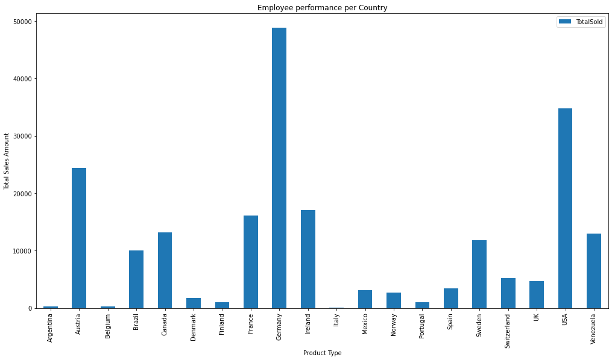

```python
# Total sold by employee by country
empSoldCountry.plot(kind="bar",figsize=(17, 9))
plt.title("Employee performance per Country")
plt.xlabel("Product Type")
plt.ylabel("Total Sales Amount")
plt.show()
```

The table below shows the 3 top products sold by the employee.

```python
top_3
```

| ProductName | TotalSold |
| --- | --- |
| Thüringer Rostbratwurst | 12378.5 |
| Gnocchi di nonna Alice | 14144.2 |
| Côte de Blaye | 25559.5 |

The table below shows the products that have not been sold by the employee before.

```python
empNotSold
```

| ProductName | TotalSold |
| --- | --- |
| Chef Anton's Gumbo Mix | 0.0 |
| Gravad lax | 0.0 |
| Northwoods Cranberry Sauce | 0.0 |

#### Summary of Janet Leverling

##### Strength

- This employee is most successful in selling beverages.
- They only have 3 products they have not been able to sell, which is better than the average.

##### Areas of improvement

- This employee has been selling less in the most recent year and should try to improve their overall sales
- This employee has sold to Italy far less than other employees and should try to sell more to Italy

### Margaret Peacock - Employee ID 4

The following code creates various statistics for an employee to measure their performance

```python
current = sort_data(4)
# dataset for total revenue by product name
empSold = current.groupby("ProductName")[["TotalSold"]].sum()
# dataset for total revenue by product category
empSoldCategory = current.groupby("CategoryName")[["TotalSold"]].sum()
# dataset for products employee didn't sell
empNotSold = empSold.loc[empSold.TotalSold == 0]
# dataset for employee's total sold by year
emp_total_sold = current.groupby(["OrderDate"])[["TotalSold"]].sum()
# Worst 3 products sold by employee
bottom_3 = empSold.sort_values(by=['TotalSold']).iloc[:3]
# best 3 products sold by employee
top_3 = empSold.sort_values(by=['TotalSold']).iloc[-3:]
# dataset for employee's total revenue by country
empSoldCountry = empSold = current.groupby("ShipCountry")[["TotalSold"]].sum()
```

The graph below shows the total sales trend of an employee by year.

It can be seen that they generated less revenue than the prior year.

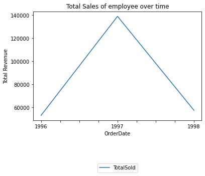

```python
# Total sold by employee over time
emp_total_sold.pivot_table(values="TotalSold", index = "OrderDate").plot()
plt.ylabel("Total Revenue")
plt.title("Total Sales of employee over time")
plt.legend(loc = "lower center", bbox_to_anchor = (0.5, -0.5))
```

The table below shows the total amount sold by an employee by category.

It can be seen that they have sold beverages the most, while Produce is sold the least.

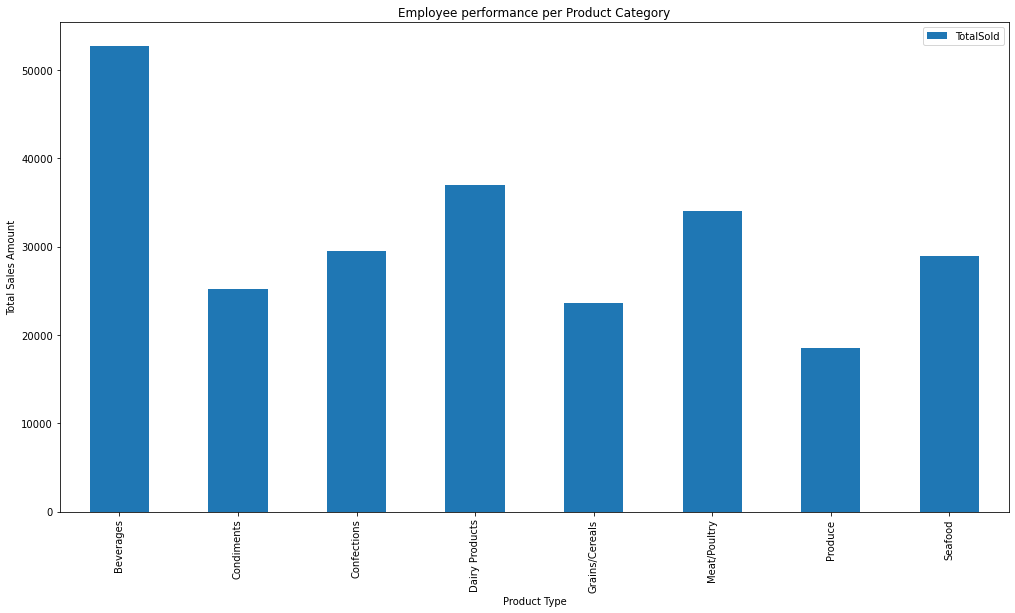

```python
# Total sold by employee by category
empSoldCategory.plot(kind="bar",figsize=(17, 9))
plt.title("Employee performance per Product Category")
plt.xlabel("Product Type")
plt.ylabel("Total Sales Amount")
```

The table below shows the total amount sold by an employee by country.

It can be seen that they have sold to the USA the most, while Poland is sold to the least.

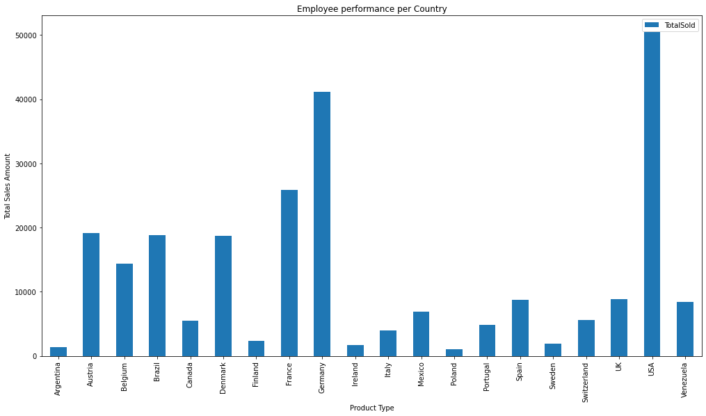

```python
# Total sold by employee by country
empSoldCountry.plot(kind="bar",figsize=(17, 9))
plt.title("Employee performance per Country")
plt.xlabel("Product Type")
plt.ylabel("Total Sales Amount")
plt.show()
```

The table below shows the 3 top products sold by the employee.

```python
top_3
```

| ProductName | TotalSold |
| --- | --- |
| Raclette Courdavault | 12352.75 |
| Thüringer Rostbratwurst | 14397.62 |
| Côte de Blaye | 30036.50 |

The table below shows the products that have not been sold by the employee before.

```python
empNotSold
```

| ProductName | TotalSold |
| --- | --- |
| Mascarpone Fabioli | 0.0 |
| Mishi Kobe Niku | 0.0 |

#### Summary of Margaret Peacock

##### Strength

- This employee has a very good overall ratio of goods sold, with most product categories being sold more than other employees
- They only have 2 products they have not managed to sell, which is far better than other employees.

##### Areas of improvement

- This employee sold significantly less in the most recent year than the prior year, which is a larger decrease than most other employees and really needs to focus on getting their sales back up

### Steven Buchanan - Employee ID 5

The following code creates various statistics for an employee to measure their performance

```python
current = sort_data(5)
# dataset for total revenue by product name
empSold = current.groupby("ProductName")[["TotalSold"]].sum()
# dataset for total revenue by product category
empSoldCategory = current.groupby("CategoryName")[["TotalSold"]].sum()
# dataset for products employee didn't sell
empNotSold = empSold.loc[empSold.TotalSold == 0]
# dataset for employee's total sold by year
emp_total_sold = current.groupby(["OrderDate"])[["TotalSold"]].sum()
# Worst 3 products sold by employee
bottom_3 = empSold.sort_values(by=['TotalSold']).iloc[:3]
# best 3 products sold by employee
top_3 = empSold.sort_values(by=['TotalSold']).iloc[-3:]
# dataset for employee's total revenue by country
empSoldCountry = empSold = current.groupby("ShipCountry")[["TotalSold"]].sum()
```

The graph below shows the total sales trend of an employee by year.

It can be seen that they generated less revenue than the prior year.

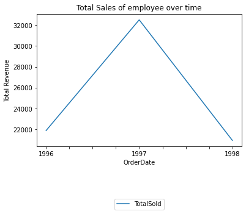

```python
# Total sold by employee over time
emp_total_sold.pivot_table(values="TotalSold", index = "OrderDate").plot()
plt.ylabel("Total Revenue")
plt.title("Total Sales of employee over time")
plt.legend(loc = "lower center", bbox_to_anchor = (0.5, -0.5))
```

The table below shows the total amount sold by an employee by category.

It can be seen that they have sold Dairy products the most, while condiminiums are sold the least.

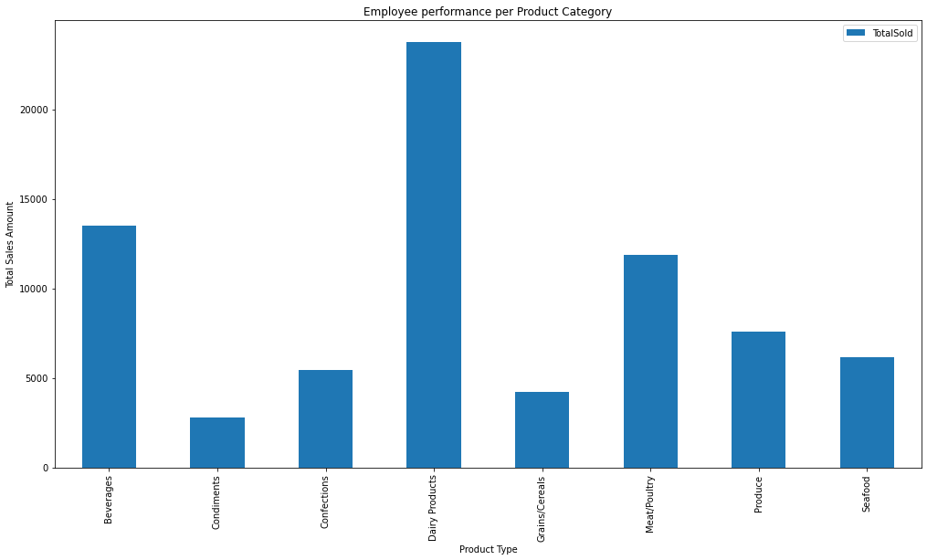

```python
# Total sold by employee by category
empSoldCategory.plot(kind="bar",figsize=(17, 9))
plt.title("Employee performance per Product Category")
plt.xlabel("Product Type")
plt.ylabel("Total Sales Amount")
```

The table below shows the total amount sold by an employee by country.

It can be seen that they have sold to Brazil the most, while Poland is sold to the least.

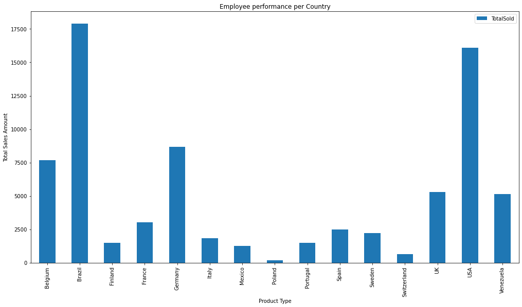

```python
# Total sold by employee by country
empSoldCountry.plot(kind="bar",figsize=(17, 9))
plt.title("Employee performance per Country")
plt.xlabel("Product Type")
plt.ylabel("Total Sales Amount")
plt.show()
```

The table below shows the 3 top products sold by the employee.

```python
top_3
```

| ProductName | TotalSold |
| --- | --- |
| Mozzarella di Giovanni | 5813.7 |
| Raclette Courdavault | 7913.9 |
| CÃ´te de Blaye | 8422.0 |

The table below shows the products that have not been sold by the employee before.

```python
empNotSold
```

| ProductName | TotalSold |
| --- | --- |
| Aniseed Syrup | 0.0 |
| Carnarvon Tigers | 0.0 |
| Chef Anton's Gumbo Mix | 0.0 |
| Chocolade | 0.0 |
| Filo Mix | 0.0 |
| Genen Shouyu | 0.0 |
| Grandma's Boysenberry Spread | 0.0 |
| Gravad lax | 0.0 |
| Gumbär Gummibärchen | 0.0 |
| Ipoh Coffee | 0.0 |
| Konbu | 0.0 |
| Laughing Lumberjack Lager | 0.0 |
| Louisiana Hot Spiced Okra | 0.0 |
| Mascarpone Fabioli | 0.0 |
| Maxilaku | 0.0 |
| Mishi Kobe Niku | 0.0 |
| Northwoods Cranberry Sauce | 0.0 |
| Outback Lager | 0.0 |
| Queso Manchego La Pastora | 0.0 |
| Röd Kaviar | 0.0 |
| Schoggi Schokolade | 0.0 |
| Sirop d'érable | 0.0 |
| Spegesild | 0.0 |
| Thüringer Rostbratwurst | 0.0 |
| Valkoinen suklaa | 0.0 |

### Michael Suyama - Employee ID 6

The following code creates various statistics for an employee to measure their performance

```python
current = sort_data(6)
# dataset for total revenue by product name
empSold = current.groupby("ProductName")[["TotalSold"]].sum()
# dataset for total revenue by product category
empSoldCategory = current.groupby("CategoryName")[["TotalSold"]].sum()
# dataset for products employee didn't sell
empNotSold = empSold.loc[empSold.TotalSold == 0]
# dataset for employee's total sold by year
emp_total_sold = current.groupby(["OrderDate"])[["TotalSold"]].sum()
# Worst 3 products sold by employee
bottom_3 = empSold.sort_values(by=['TotalSold']).iloc[:3]
# best 3 products sold by employee
top_3 = empSold.sort_values(by=['TotalSold']).iloc[-3:]
# dataset for employee's total revenue by country
empSoldCountry = empSold = current.groupby("ShipCountry")[["TotalSold"]].sum()
```

The graph below shows the total sales trend of an employee by year.

It can be seen that they generated less revenue than the prior year.

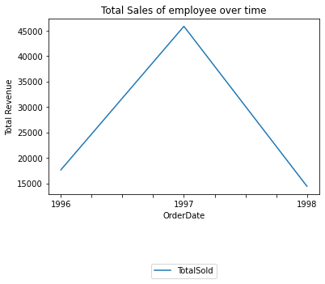

```python
# Total sold by employee over time
emp_total_sold.pivot_table(values="TotalSold", index = "OrderDate").plot()
plt.ylabel("Total Revenue")
plt.title("Total Sales of employee over time")
plt.legend(loc = "lower center", bbox_to_anchor = (0.5, -0.5))
```

The table below shows the total amount sold by an employee by category.

It can be seen that they have sold Dairy products the most, while condiminiums are sold the least.

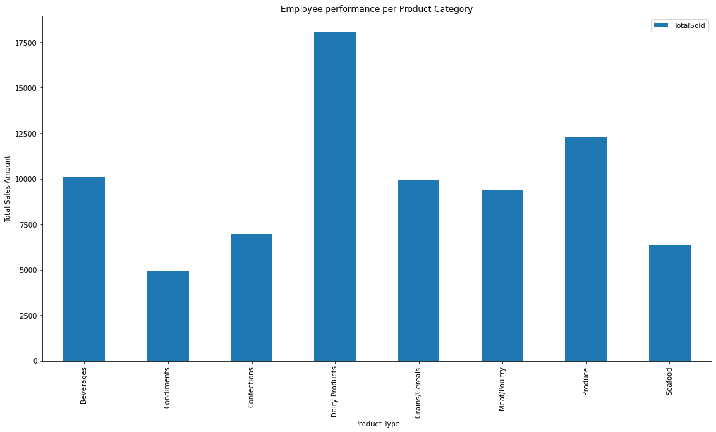

```python
# Total sold by employee by category
empSoldCategory.plot(kind="bar",figsize=(17, 9))
plt.title("Employee performance per Product Category")
plt.xlabel("Product Type")
plt.ylabel("Total Sales Amount")
```

The table below shows the total amount sold by an employee by country.

It can be seen that they have sold to the USA the most, while Italy and Argentina is sold to the least.

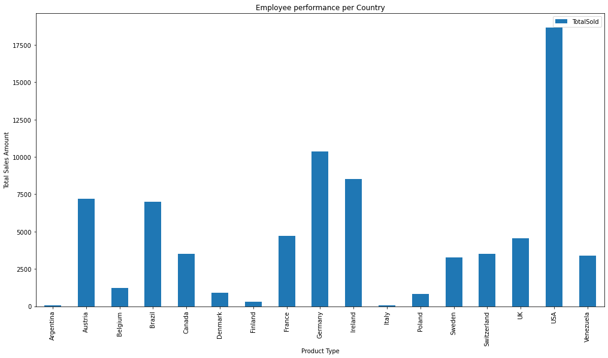

```python
# Total sold by employee by country
empSoldCountry.plot(kind="bar",figsize=(17, 9))
plt.title("Employee performance per Country")
plt.xlabel("Product Type")
plt.ylabel("Total Sales Amount")
plt.show()
```

The table below shows the 3 top products sold by the employee.

```python
top_3
```

| ProductName | TotalSold |
| --- | --- |
| ThÃ¼ringer Rostbratwurst | 6188.8 |
| Gnocchi di nonna Alice | 6750.0 |
| Raclette Courdavault | 7334.2 |

The table below shows the products that have not been sold by the employee before.

```python
empNotSold
```

| ProductName | TotalSold |
| --- | --- |
| Alice Mutton | 0.0 |
| Carnarvon Tigers | 0.0 |
| Côte de Blaye | 0.0 |
| Escargots de Bourgogne | 0.0 |
| Grandma's Boysenberry Spread | 0.0 |
| Gravad lax | 0.0 |
| Gustaf's Knäckebröd | 0.0 |
| Ipoh Coffee | 0.0 |
| Laughing Lumberjack Lager | 0.0 |
| Louisiana Hot Spiced Okra | 0.0 |
| Mascarpone Fabioli | 0.0 |
| Mishi Kobe Niku | 0.0 |
| Nord-Ost Matjeshering | 0.0 |
| Northwoods Cranberry Sauce | 0.0 |
| NuNuCa Nuß-Nougat-Creme | 0.0 |
| Rogede sild | 0.0 |
| Schoggi Schokolade | 0.0 |
| Scottish Longbreads | 0.0 |
| Singaporean Hokkien Fried Mee | 0.0 |
| Tunnbröd | 0.0 |

#### Summary of Michael Suyama

##### Strength

- This employee is most successful in selling Dairy products.

### Robert King - Employee ID 7

The following code creates various statistics for an employee to measure their performance

```python
current = sort_data(7)
# dataset for total revenue by product name
empSold = current.groupby("ProductName")[["TotalSold"]].sum()
# dataset for total revenue by product category
empSoldCategory = current.groupby("CategoryName")[["TotalSold"]].sum()
# dataset for products employee didn't sell
empNotSold = empSold.loc[empSold.TotalSold == 0]
# dataset for employee's total sold by year
emp_total_sold = current.groupby(["OrderDate"])[["TotalSold"]].sum()
# Worst 3 products sold by employee
bottom_3 = empSold.sort_values(by=['TotalSold']).iloc[:3]
# best 3 products sold by employee
top_3 = empSold.sort_values(by=['TotalSold']).iloc[-3:]
# dataset for employee's total revenue by country
empSoldCountry = empSold = current.groupby("ShipCountry")[["TotalSold"]].sum()
```

The graph below shows the total sales trend of an employee by year.

It can be seen that they generated less revenue than the prior year.

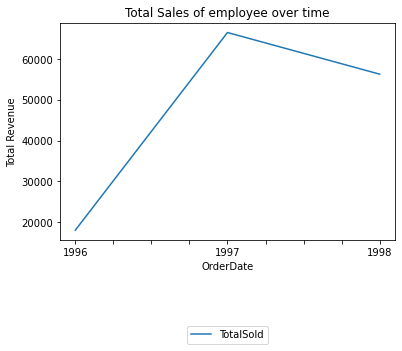

```python
# Total sold by employee over time
emp_total_sold.pivot_table(values="TotalSold", index = "OrderDate").plot()
plt.ylabel("Total Revenue")
plt.title("Total Sales of employee over time")
plt.legend(loc = "lower center", bbox_to_anchor = (0.5, -0.5))
```

The table below shows the total amount sold by an employee by category.

It can be seen that they have sold beverages the most, while grains/cereals are sold the least.

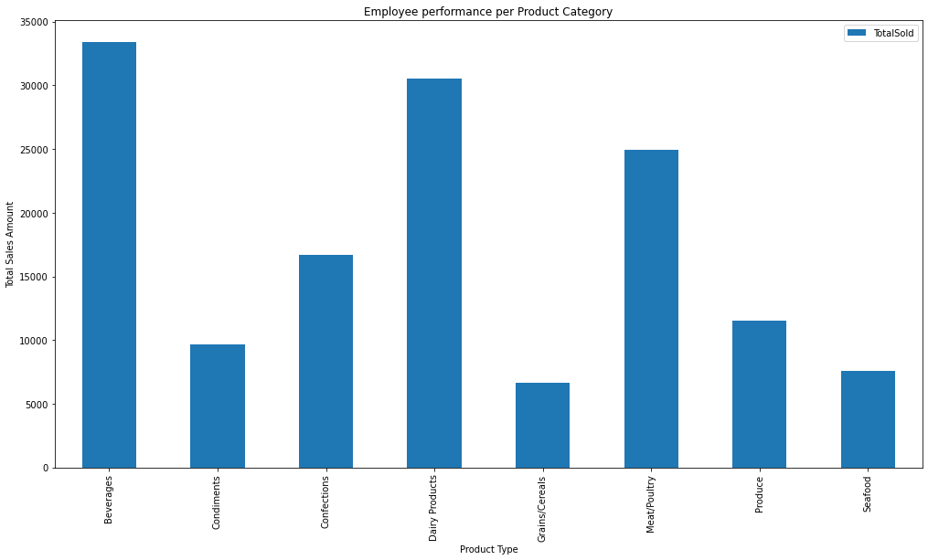

```python
# Total sold by employee by category
empSoldCategory.plot(kind="bar",figsize=(17, 9))
plt.title("Employee performance per Product Category")
plt.xlabel("Product Type")
plt.ylabel("Total Sales Amount")
```

The table below shows the total amount sold by an employee by country.

It can be seen that they have sold to Austria and the USA the most, while Portugal is sold to the least.

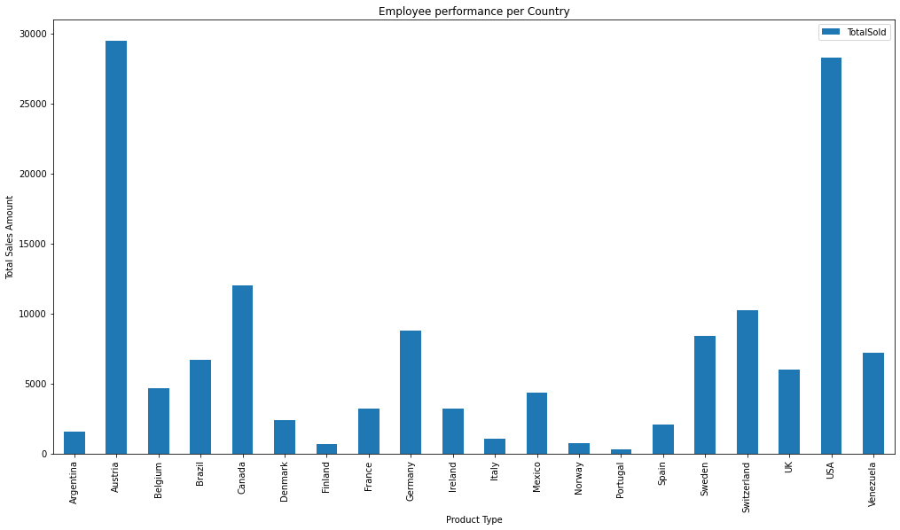

```python
# Total sold by employee by country
empSoldCountry.plot(kind="bar",figsize=(17, 9))
plt.title("Employee performance per Country")
plt.xlabel("Product Type")
plt.ylabel("Total Sales Amount")
plt.show()
```

The table below shows the 3 top products sold by the employee.

```python
top_3
```

| ProductName | TotalSold |
| --- | --- |
| Raclette Courdavault | 10544.65 |
| Thüringer Rostbratwurst | 18045.84 |
| Côte de Blaye | 20849.40 |

The table below shows the products that have not been sold by the employee before.

```python
empNotSold
```

| ProductName | TotalSold |
| --- | --- |
| Genen Shouyu | 0.0 |
| Grandma's Boysenberry Spread | 0.0 |
| Gula Malacca | 0.0 |
| Longlife Tofu | 0.0 |
| Pâté chinois | 0.0 |
| Röd Kaviar | 0.0 |
| Schoggi Schokolade | 0.0 |
| Tofu | 0.0 |
| Valkoinen suklaa | 0.0 |
| Vegie-spread | 0.0 |

#### Summary of Robert King

##### Areas of improvement

- This employee has 10 types of products they have never sold before. While they are already doing better than most other emplyoees, finding a way to sell these 10 products could increase their overall sales revenue even more.

### Callahan Laura - Employee ID 8

The following code creates various statistics for an employee to measure their performance

```python
current = sort_data(8)
# dataset for total revenue by product name
empSold = current.groupby("ProductName")[["TotalSold"]].sum()
# dataset for total revenue by product category
empSoldCategory = current.groupby("CategoryName")[["TotalSold"]].sum()
# dataset for products employee didn't sell
empNotSold = empSold.loc[empSold.TotalSold == 0]
# dataset for employee's total sold by year
emp_total_sold = current.groupby(["OrderDate"])[["TotalSold"]].sum()
# Worst 3 products sold by employee
bottom_3 = empSold.sort_values(by=['TotalSold']).iloc[:3]
# best 3 products sold by employee
top_3 = empSold.sort_values(by=['TotalSold']).iloc[-3:]
# dataset for employee's total revenue by country
empSoldCountry = empSold = current.groupby("ShipCountry")[["TotalSold"]].sum()
```

The graph below shows the total sales trend of an employee by year.

It can be seen that they generated less revenue than the prior year.

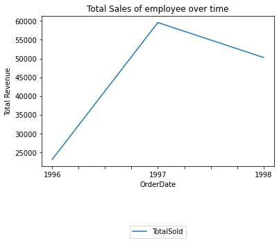

```python
# Total sold by employee over time
emp_total_sold.pivot_table(values="TotalSold", index = "OrderDate").plot()
plt.ylabel("Total Revenue")
plt.title("Total Sales of employee over time")
plt.legend(loc = "lower center", bbox_to_anchor = (0.5, -0.5))
```

The table below shows the total amount sold by an employee by category.

It can be seen that they have sold confections the most, while grains/cereals are sold the least.

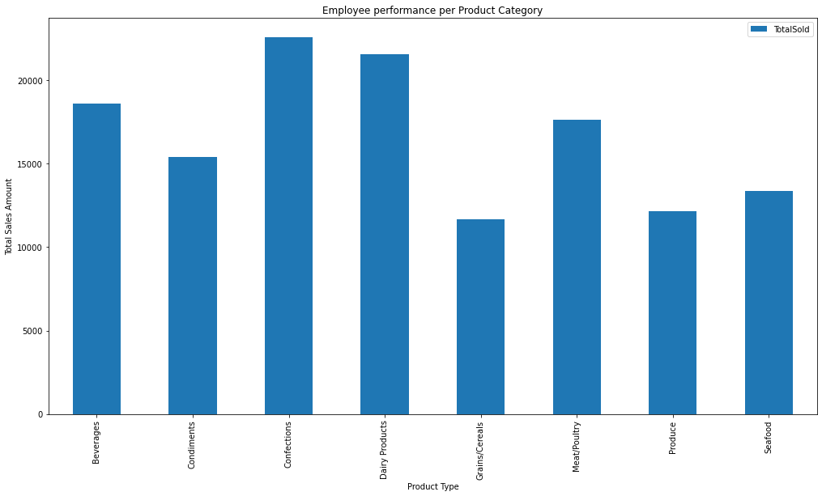

```python
# Total sold by employee by category
empSoldCategory.plot(kind="bar",figsize=(17, 9))
plt.title("Employee performance per Product Category")
plt.xlabel("Product Type")
plt.ylabel("Total Sales Amount")
```

The table below shows the total amount sold by an employee by country.

It can be seen that they have sold to Germany and the US the most, while Spain is sold to the least.

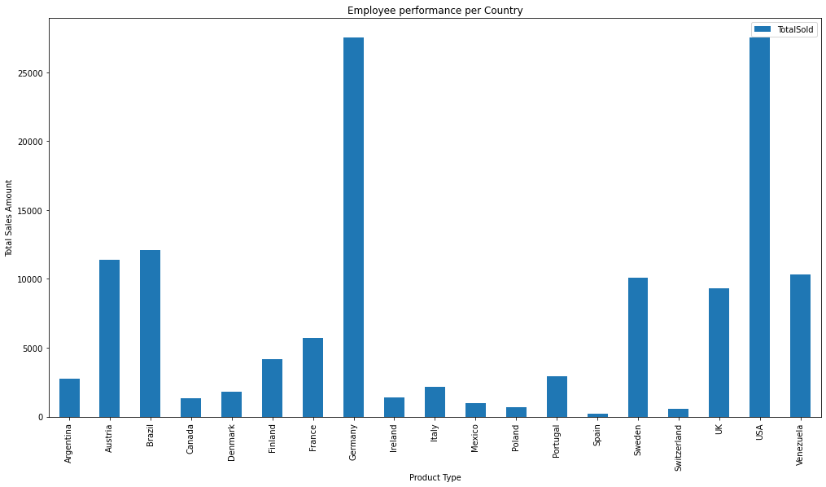

```python
# Total sold by employee by country
empSoldCountry.plot(kind="bar",figsize=(17, 9))
plt.title("Employee performance per Country")
plt.xlabel("Product Type")
plt.ylabel("Total Sales Amount")
plt.show()
```

The table below shows the 3 top products sold by the employee.

```python
top_3
```

| ProductName | TotalSold |
| --- | --- |
| Tarte au sucre | 7781.05 |
| Uncle Bob's Organic Dried Pears | 8190.00 |
| ThÃ¼ringer Rostbratwurst | 9796.80 |

The table below shows the products that have not been sold by the employee before.

```python
empNotSold
```

| ProductName | TotalSold |
| --- | --- |
| Chocolade | 0.0 |
| CÃ´te de Blaye | 0.0 |
| Genen Shouyu | 0.0 |
| Grandma's Boysenberry Spread | 0.0 |
| Louisiana Hot Spiced Okra | 0.0 |
| Mishi Kobe Niku | 0.0 |
| Rogede sild | 0.0 |

#### Summary of Callahan Laura

##### Areas of improvement

- This employee has been selling less in the most recent year and should try to improve their overall sales.
- This employee has 7 types of products they have never sold before. This is about an average amount for most employees, but shows an area they can work on to increase total sales.

### Anne Dodsworth - Employee ID 9

The following code creates various statistics for an employee to measure their performance

```python
current = sort_data(9)
# dataset for total revenue by product name
empSold = current.groupby("ProductName")[["TotalSold"]].sum()
# dataset for total revenue by product category
empSoldCategory = current.groupby("CategoryName")[["TotalSold"]].sum()
# dataset for products employee didn't sell
empNotSold = empSold.loc[empSold.TotalSold == 0]
# dataset for employee's total sold by year
emp_total_sold = current.groupby(["OrderDate"])[["TotalSold"]].sum()
# Worst 3 products sold by employee
bottom_3 = empSold.sort_values(by=['TotalSold']).iloc[:3]
# best 3 products sold by employee
top_3 = empSold.sort_values(by=['TotalSold']).iloc[-3:]
# dataset for employee's total revenue by country
empSoldCountry = empSold = current.groupby("ShipCountry")[["TotalSold"]].sum()
```

The graph below shows the total sales trend of an employee by year.

It can be seen that they generated more revenue than the prior year.

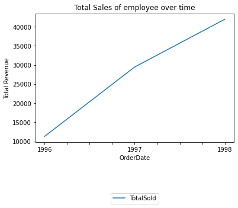

```python
# Total sold by employee over time
emp_total_sold.pivot_table(values="TotalSold", index = "OrderDate").plot()
plt.ylabel("Total Revenue")
plt.title("Total Sales of employee over time")
plt.legend(loc = "lower center", bbox_to_anchor = (0.5, -0.5))
```

The table below shows the total amount sold by an employee by category.

It can be seen that they have sold Dairy products the most, while produce is sold the least.

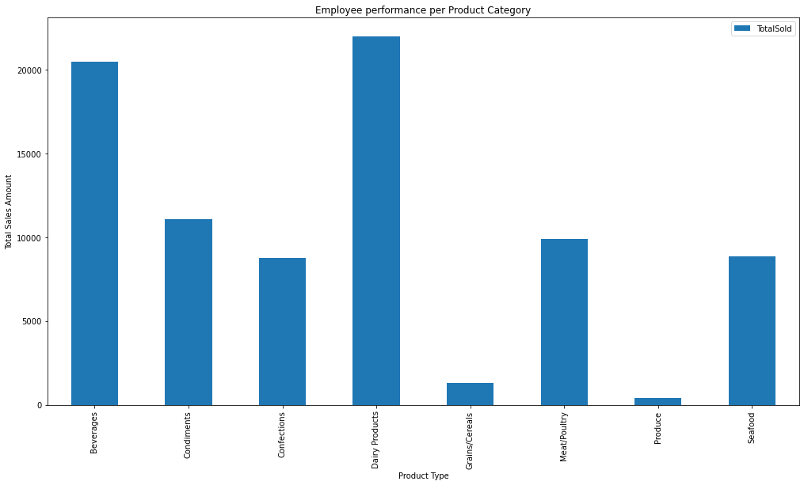

```python
# Total sold by employee by category
empSoldCategory.plot(kind="bar",figsize=(17, 9))
plt.title("Employee performance per Product Category")
plt.xlabel("Product Type")
plt.ylabel("Total Sales Amount")
```

The table below shows the total amount sold by an employee by country.

It can be seen that they have sold to the USA the most, while Portugal is sold to the least.

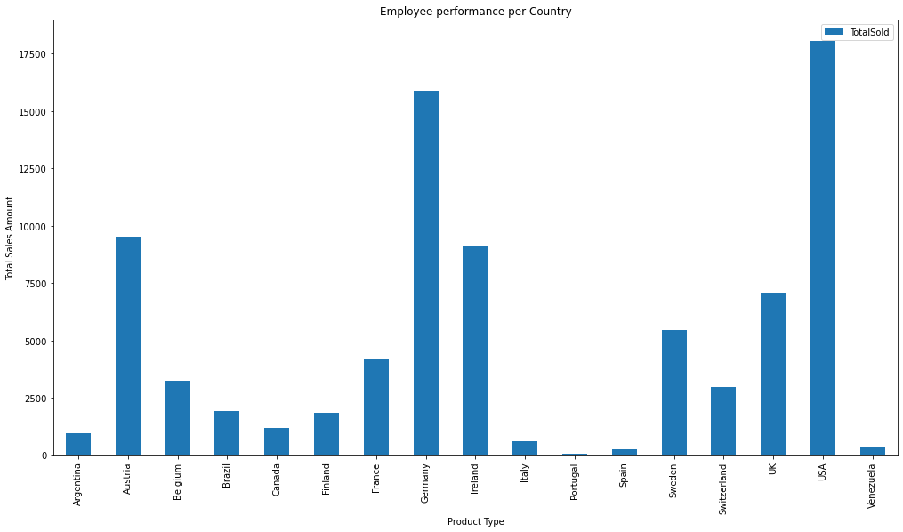

```python
# Total sold by employee by country
empSoldCountry.plot(kind="bar",figsize=(17, 9))
plt.title("Employee performance per Country")
plt.xlabel("Product Type")
plt.ylabel("Total Sales Amount")
plt.show()
```

The table below shows the 3 top products sold by the employee.

```python
top_3
```

| ProductName | TotalSold |
| --- | --- |
| Mishi Kobe Niku | 4837.50 |
| Raclette Courdavault | 14739.45 |
| CÃ´te de Blaye | 15018.00 |

The table below shows the products that have not been sold by the employee before.

```python
empNotSold
```

| ProductName | TotalSold |
| --- | --- |
| Chef Anton's Cajun Seasoning | 0.0 |
| Chef Anton's Gumbo Mix | 0.0 |
| Chocolade | 0.0 |
| Escargots de Bourgogne | 0.0 |
| Genen Shouyu | 0.0 |
| Gnocchi di nonna Alice | 0.0 |
| Gravad lax | 0.0 |
| Gustaf's Knäckebröd | 0.0 |
| Ipoh Coffee | 0.0 |
| Laughing Lumberjack Lager | 0.0 |
| Manjimup Dried Apples | 0.0 |
| Perth Pasties | 0.0 |
| Pâté chinois | 0.0 |
| Queso Manchego La Pastora | 0.0 |
| Ravioli Angelo | 0.0 |
| Röd Kaviar | 0.0 |
| Rössle Sauerkraut | 0.0 |
| Schoggi Schokolade | 0.0 |
| Scottish Longbreads | 0.0 |
| Singaporean Hokkien Fried Mee | 0.0 |
| Tarte au sucre | 0.0 |
| Tunnbröd | 0.0 |
| Uncle Bob's Organic Dried Pears | 0.0 |
| Valkoinen suklaa | 0.0 |

#### Summary of Anne Dodsworth

##### Strength

- This employee is most successful in selling dairy products
- They are only 1 of 2 employees that managed to increase sales in the most recent year.

##### Areas of improvement

- This employee has sold to portugal significantly less than other employees. They may want to focus on trying to sell more there.
- This employee has 24 types of products they have never sold before, which is significantly higher than the average amoung other employees. If they have been able to have a large total sales amount so far, they may be able to drastically improve their total revenue generated by trying to sell some of the 24 products they have not before.

# Part3

*For part 3, We are going to use pandas-on-spark Data Frame to view different variable means across season from the NFL dataset. Using pandas-on-spark will make things easier than the method that was used in HW4. After finding the mean and standard deviation for the `Quarter` variable, we will convert the pandas-on-spark dataframe back to a normal pandas data frame and plot the data.*

Import modules that we need for data frame transformation and calculation of means

```python
import os
import sys
os.environ['PYSPARK_PYTHON'] = sys.executable
os.environ['PYSPARK_DRIVER_PYTHON'] = sys.executable

import pandas as pd
import numpy as np
import pyspark.pandas as ps
from pyspark.sql import SparkSession
import matplotlib.pyplot as plt
```

```
WARNING:root:'PYARROW_IGNORE_TIMEZONE' environment variable was not set. It is required to set this environment variable to '1' in both driver and executor sides if you use pyarrow>=2.0.0. pandas-on-Spark will set it for you but it does not work if there is a Spark context already launched.
```

Reading in the full NFL csv dataset and covert it into pandas-on-Spark data frame

```python
pdf = pd.read_csv("https://www4.stat.ncsu.edu/~online/datasets/scoresFull.csv")
psdf = ps.from_pandas(pdf)
```

Use for loop to specify which variable in the data is needed to view, and extract the information of these three variables and append each of them into three different lists

```python
Mean = []
Std = []
Name = []
for i in list(psdf.columns):
    if i in ['AQ1','AQ2','AQ3','AQ4','AFinal','HQ1','HQ2','HQ3','HQ4','HFinal']:
        Mean.append(psdf[i].mean())
        Std.append(psdf[i].std())
        Name.append(str(i))
    else:
        continue
```

Zip the three list into one Data frame for future usage

```python
Mean_psdf = pd.DataFrame(zip(Name,Mean,Std),columns = ["Variable","Mean","Std"])
Mean_psdf
```

|  | Variable | Mean | Std |
| --- | --- | --- | --- |
| 0 | AQ1 | 3.924806 | 4.490700 |
| 1 | AQ2 | 6.241429 | 5.221593 |
| 2 | AQ3 | 4.386920 | 4.632717 |
| 3 | AQ4 | 5.890233 | 5.278775 |
| 4 | AFinal | 20.557188 | 10.195586 |
| 5 | HQ1 | 4.828868 | 4.726903 |
| 6 | HQ2 | 7.105157 | 5.702788 |
| 7 | HQ3 | 4.791126 | 4.755145 |
| 8 | HQ4 | 6.322962 | 5.417310 |
| 9 | HFinal | 23.174013 | 10.405952 |

Use the method `groupby` and `mean` method to build a data frame that contains the mean for each required variables across seasons

```python
meanps = psdf.groupby("season").mean()
meanps = meanps[['AQ1', 'AQ2', 'AQ3',
'AQ4', 'AFinal', 'HQ1', 'HQ2', 'HQ3', 'HQ4', 'HFinal']]
meanps
```

| season | AQ1 | AQ2 | AQ3 | AQ4 | AFinal | HQ1 | HQ2 | HQ3 | HQ4 | HFinal |
| --- | --- | --- | --- | --- | --- | --- | --- | --- | --- | --- |
| 2003 | 3.558052 | 6.093633 | 3.913858 | 5.355805 | 19.112360 | 5.026217 | 6.625468 | 4.561798 | 6.295880 | 22.677903 |
| 2002 | 4.037453 | 6.022472 | 4.449438 | 5.928839 | 20.640449 | 4.307116 | 7.411985 | 4.715356 | 6.426966 | 23.018727 |
| 2004 | 3.913858 | 6.265918 | 4.153558 | 5.797753 | 20.239700 | 4.943820 | 7.071161 | 4.250936 | 6.561798 | 22.906367 |
| 2005 | 3.887640 | 5.543071 | 4.029963 | 5.191011 | 18.786517 | 4.393258 | 7.426966 | 4.677903 | 5.737828 | 22.314607 |
| 2006 | 3.629213 | 6.179775 | 4.303371 | 6.063670 | 20.254682 | 4.606742 | 6.041199 | 4.565543 | 5.932584 | 21.258427 |
| 2007 | 3.696629 | 6.220974 | 4.337079 | 5.872659 | 20.228464 | 5.026217 | 7.074906 | 4.913858 | 6.018727 | 23.157303 |
| 2008 | 3.801498 | 6.498127 | 4.074906 | 6.423221 | 20.842697 | 5.179775 | 7.205993 | 4.595506 | 6.044944 | 23.183521 |
| 2009 | 3.868914 | 6.202247 | 4.299625 | 5.943820 | 20.382022 | 4.737828 | 7.790262 | 4.228464 | 5.887640 | 22.779026 |
| 2010 | 3.973783 | 6.865169 | 4.629213 | 5.704120 | 21.318352 | 4.576779 | 6.771536 | 4.868914 | 6.681648 | 23.000000 |
| 2011 | 3.857678 | 5.981273 | 4.584270 | 5.996255 | 20.509363 | 5.022472 | 7.333333 | 5.033708 | 6.479401 | 23.981273 |
| 2012 | 4.468165 | 6.273408 | 4.509363 | 6.235955 | 21.655431 | 4.928839 | 7.003745 | 5.217228 | 6.823970 | 24.119850 |
| 2013 | 4.044944 | 6.670412 | 5.011236 | 6.183521 | 21.977528 | 5.112360 | 7.445693 | 5.258427 | 6.932584 | 24.891386 |
| 2014 | 4.284644 | 6.322097 | 4.734082 | 5.876404 | 21.295880 | 4.913858 | 7.164794 | 5.397004 | 6.374532 | 23.973783 |

The pandas-on-spark data frame is converted to a normal pandas data frame

```python
one = meanps.to_pandas()
two = one.sort_values(by = ['season'])
two
```

| season | AQ1 | AQ2 | AQ3 | AQ4 | AFinal | HQ1 | HQ2 | HQ3 | HQ4 | HFinal |
| --- | --- | --- | --- | --- | --- | --- | --- | --- | --- | --- |
| 2002 | 4.037453 | 6.022472 | 4.449438 | 5.928839 | 20.640449 | 4.307116 | 7.411985 | 4.715356 | 6.426966 | 23.018727 |
| 2003 | 3.558052 | 6.093633 | 3.913858 | 5.355805 | 19.112360 | 5.026217 | 6.625468 | 4.561798 | 6.295880 | 22.677903 |
| 2004 | 3.913858 | 6.265918 | 4.153558 | 5.797753 | 20.239700 | 4.943820 | 7.071161 | 4.250936 | 6.561798 | 22.906367 |
| 2005 | 3.887640 | 5.543071 | 4.029963 | 5.191011 | 18.786517 | 4.393258 | 7.426966 | 4.677903 | 5.737828 | 22.314607 |
| 2006 | 3.629213 | 6.179775 | 4.303371 | 6.063670 | 20.254682 | 4.606742 | 6.041199 | 4.565543 | 5.932584 | 21.258427 |
| 2007 | 3.696629 | 6.220974 | 4.337079 | 5.872659 | 20.228464 | 5.026217 | 7.074906 | 4.913858 | 6.018727 | 23.157303 |
| 2008 | 3.801498 | 6.498127 | 4.074906 | 6.423221 | 20.842697 | 5.179775 | 7.205993 | 4.595506 | 6.044944 | 23.183521 |
| 2009 | 3.868914 | 6.202247 | 4.299625 | 5.943820 | 20.382022 | 4.737828 | 7.790262 | 4.228464 | 5.887640 | 22.779026 |
| 2010 | 3.973783 | 6.865169 | 4.629213 | 5.704120 | 21.318352 | 4.576779 | 6.771536 | 4.868914 | 6.681648 | 23.000000 |
| 2011 | 3.857678 | 5.981273 | 4.584270 | 5.996255 | 20.509363 | 5.022472 | 7.333333 | 5.033708 | 6.479401 | 23.981273 |
| 2012 | 4.468165 | 6.273408 | 4.509363 | 6.235955 | 21.655431 | 4.928839 | 7.003745 | 5.217228 | 6.823970 | 24.119850 |
| 2013 | 4.044944 | 6.670412 | 5.011236 | 6.183521 | 21.977528 | 5.112360 | 7.445693 | 5.258427 | 6.932584 | 24.891386 |
| 2014 | 4.284644 | 6.322097 | 4.734082 | 5.876404 | 21.295880 | 4.913858 | 7.164794 | 5.397004 | 6.374532 | 23.973783 |

Utilize `plot` method to plot the mean data frame after converting

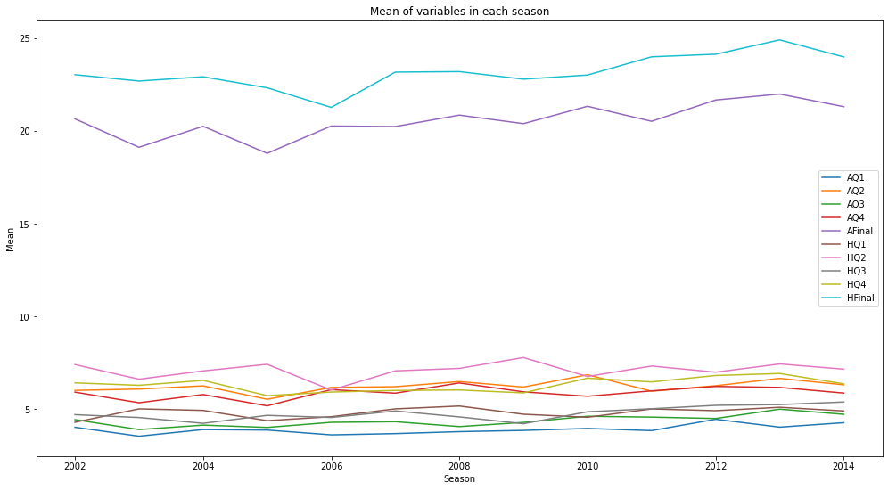

```python
two.plot(figsize=(17, 9))

plt.title("Mean of variables in each season")

plt.xlabel("Season")

plt.ylabel("Mean")
```

*The plot above shows that HFinal and AFinal have much larger means than all other variables. Considering that they are the sum of the final score for a game, it is reasonable for this to happen. We can also see that on average, games played at home have a higher final score than a game played away.*